# R code

James Billingsley

2021-07-02

```r
library(Seurat)
library(Matrix)
library(RCurl)
library(knitr)
library(reticulate)
library(ensembldb)
library(AnnotationHub)
library(tidyverse)
library(sctransform)
```

32 single-cell transcriptome libraries generated from eight tumor samples were sequenced in two sequencing runs (16 libraries/run). A subset of the single-cell transcriptome data contains the D4M.3A-pOVA data which we called allntova (All cells, Not aPD1 Treated, pOVA immunogenic tumor). The allntova subset was used for all subsequent downstream analyses performed in this study (the single-cell transcriptome data that we provide on GEO is also only the allntova subset data). In this notebook the two separate sequencing runs are merged, the resulting raw gene matrix is filtered for high quality single-cell transcriptomes, the allntova subset of the filtered matrix is selected, and cell counts are normalized with the SCTransform function from the Seurat package. To reduce dimensions, Principal Component Analysis was performed using the function RunPCA from the Seurat package set to 15 Principal Components. Lastly, a nearest neighbor graph and UMAP were created with the functions FindNeighbors and runUMAP from the Seurat package

Read data sets into merged seurat objects

```r
sampleBarcodes <- scan("untitled text 14.txt", what = "character")


FileList <- sampleBarcodes


for (i in 1:16) {


    MatName <- paste("/Users/hbc/Orchestra/Pittet1-", FileList[i],
        "/Pittet-", FileList[i], ".mtx", sep = "")

    GenIds <- paste("/Users/hbc/Orchestra/Pittet1-", FileList[i],
        "/Pittet-", FileList[i], ".mtx.rownames", sep = "")

    CellIds <- paste("/Users/hbc/Orchestra/Pittet1-", FileList[i],
        "/Pittet-", FileList[i], ".mtx.colnames", sep = "")

    # readin the count matrix
    counts <- readMM(MatName)
    gene_ids <- read_tsv(GenIds, col_names = FALSE)$X1
    cell_ids <- read_tsv(CellIds, col_names = FALSE)$X1
    counts <- as(counts, "dgCMatrix")

    # add row names to the count matrix to be the gene IDs, and
    # the column names of the count matrix to be the cell IDs.
    # Make the column names as the cell IDs and the row names as
    # the gene IDs
    rownames(counts) <- gene_ids

    colnames(counts) <- cell_ids

    sample <- paste0("sample", i)

    # create a seurat object
    SO <- CreateSeuratObject(counts, project = sample, assay = "RNA",
        min.cells = 3, min.features = 200)



    assign(sample, SO)

}


mergDat1 <- merge(x = sample1, y = list(sample2, sample3, sample4,
    sample5, sample6, sample7, sample8, sample9, sample10, sample11,
    sample12, sample13, sample14, sample15, sample16), add.cell.ids = FileList,
    project = "mergDat")
```

```r
sampleBarcodes <- scan("./Desktop/untitled text 16.txt", what = "character")

FileList <- sampleBarcodes

for (i in 1:16) {


    MatName <- paste("/Users/hbc/Orchestra/Pittet2-", FileList[i],
        "/Pittet-", FileList[i], ".mtx", sep = "")

    GenIds <- paste("/Users/hbc/Orchestra/Pittet2-", FileList[i],
        "/Pittet-", FileList[i], ".mtx.rownames", sep = "")

    CellIds <- paste("/Users/hbc/Orchestra/Pittet2-", FileList[i],
        "/Pittet-", FileList[i], ".mtx.colnames", sep = "")

    # readin the count matrix
    counts <- readMM(MatName)
    gene_ids <- read_tsv(GenIds, col_names = FALSE)$X1
    cell_ids <- read_tsv(CellIds, col_names = FALSE)$X1
    counts <- as(counts, "dgCMatrix")

    # add row names to the count matrix to be the gene IDs, and
    # the column names of the count matrix to be the cell IDs.
    # Make the column names as the cell IDs and the row names as
    # the gene IDs
    rownames(counts) <- gene_ids

    colnames(counts) <- cell_ids

    sample <- paste0("sample2_", i)

    # create a seurat object
    SO <- CreateSeuratObject(counts, project = sample, assay = "RNA",
        min.cells = 3, min.features = 200)



    assign(sample, SO)
}


mergDat2 <- merge(x = sample2_1, y = list(sample2_2, sample2_3,
    sample2_4, sample2_5, sample2_6, sample2_7, sample2_8, sample2_9,
    sample2_10, sample2_11, sample2_12, sample2_13, sample2_14,
    sample2_15, sample2_16), add.cell.ids = FileList, project = "mergDat2")
```

Merge the two datasets

```r
mDc <- merge(x = mergDat1, y = mergDat2, project = "combinedSets")
```

```r
# seurat object mDc was saved for convenience saveRDS(mDc,
# file='~/Desktop/mDc.rds')
```

```r
mDc <- readRDS(file = "~/Desktop/mDc.rds")
```

Filter the data

```r
log10GenesPerUMI <- log10(mDc@meta.data$nFeature_RNA)/log10(mDc@meta.data$nCount_RNA)

mDc$novelty <- log10GenesPerUMI

ah <- AnnotationHub()

ahDb <- query(ah, pattern = c("Mus musculus", "EnsDb"), ignore.case = TRUE)

id <- ahDb %>% mcols() %>% rownames() %>% tail(n = 1)

edb <- ah[[id]]

annotations <- genes(edb, return.type = "data.frame")

annotations <- annotations %>% dplyr::select(gene_id, gene_name,
    seq_name, gene_biotype, description)

mt <- annotations %>% dplyr::filter(seq_name == "MT") %>% dplyr::pull(gene_id)


mDc[["percent.mt"]] <- PercentageFeatureSet(object = mDc, features = mt[which(mt %in%
    rownames(mDc))])



mDc <- subset(mDc, subset = nCount_RNA > 350 & nCount_RNA < 6000 &
    nFeature_RNA > 250 & nFeature_RNA < 7000 & novelty > 0.9 &
    percent.mt < 10.5)
```

Transform the filtered data

```r
mDc <- SCTransform(mDc)
```

Read in and add sample annotation to the data

```r
PittetSampAn <- read.table("/Users/hbc/Desktop/PittetSampleAn.txt",
    sep = "\t", h = T)


# relevel the dataframe, order rows by levels of orig.ident,
# ie 'sample1'


mv <- match(levels(factor(mDc$orig.ident)), PittetSampAn$FileListName)


mDc$expClass <- factor(mDc$orig.ident)

levels(mDc$expClass) <- PittetSampAn$expclass[mv]
```

Subset the data to collect allntova cells

```r
Idents(mDc) <- "expClass"

SubDF <- subset(mDc, idents = c("CTRL_1immgen", "CTRL_2immgen"))
```

Run PCA, FindNeighbors, FindClusters, runUMAP

```r
SubDF <- RunPCA(object = SubDF, npcs = 15, verbose = TRUE)

SubDF <- FindNeighbors(object = SubDF, reduction = "pca", dims = 1:15)

SubDF <- FindClusters(object = SubDF, algorithm = 1, resolution = c(0.2,
    0.4, 0.6, 0.8, 1, 1.2, 1.4, 1.6, 1.8), random.seed = 42)


SubDF <- RunUMAP(object = SubDF, dims = 1:15)
```

Plot UMAP reduction

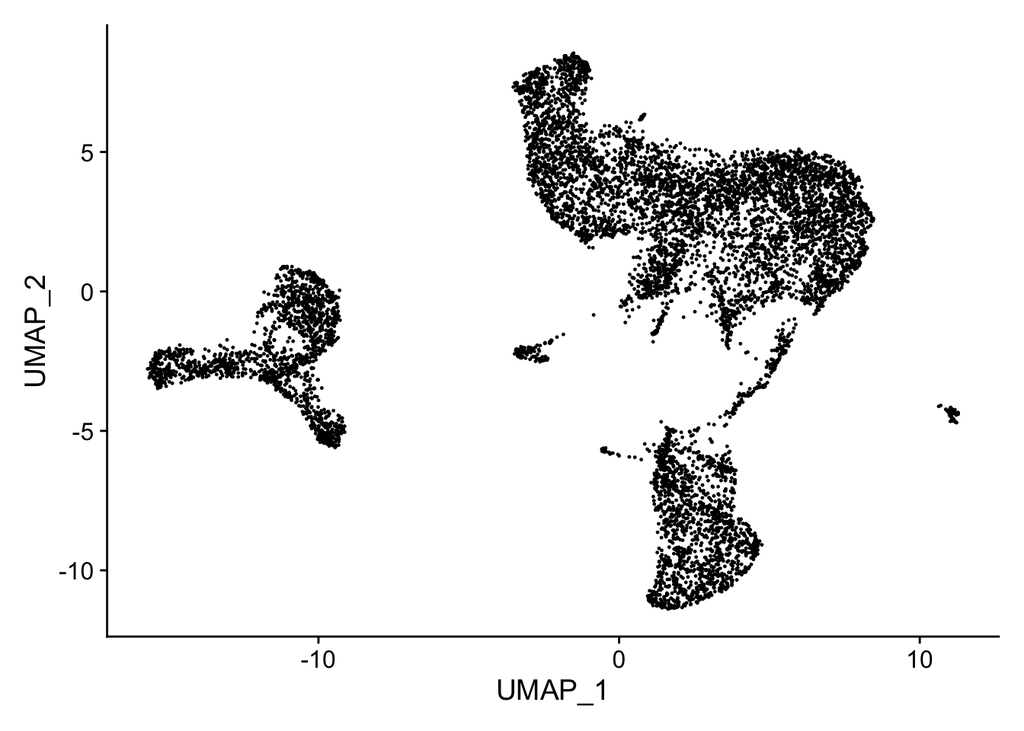

```r
Idents(SubDF) <- "expClass"


DimPlot(SubDF, reduction = "umap", cols = c("black", "black")) &
    NoLegend()
```